# Checking Locations Report

Kendra Wyant

2020-09-18

### Notes

This script checks data from RISK participants’ locations reports by computing descriptives and checking for missingness and potential errors.

Thoughts for discussion:  
1. Time of visit refers to study visit when location was identified. How can we link to gps data with time of location visit?  
2. Location_type “other” was 2nd most common choice. Locate paper files to analyze what these locations are.  
3. Not much variability in yes and no questions. Ex: Less than 4% answered “yes” to vacationing at location question.

### Setup

Paths

```r
getwd()
```

```
## [1] "/Volumes/private/StudyData/RISK"
```

```r
path_data <- "./analysis/shared/data"
```

Packages

```r
library(tidyverse)
library(janitor)
library(lubridate)
library(kableExtra)
```

### Import Data and glimpse

Locations data

```r
locations <- read_rds(file.path(path_data, "ds_locations_report.rds"))

locations <- locations %>%
  mutate(time_central = as_datetime(utc, tz = 'America/Chicago')) %>%
  select(-utc) %>%
  glimpse()
```

```
## Observations: 5,231
## Variables: 15
## $ subid          <dbl> 1, 1, 1, 1, 1, 1, 1, 1, 1, 1, 1, 1, 1, 1, 1, 1, 1, 1, …
## $ street_address <chr> "610 Merryturn Road", "4521 Cottage Grove Road", "5309…
## $ city           <chr> "Madison", "Madison", "Madison", "Madison", "Madison",…
## $ state          <chr> "WI", "WI", "WI", "WI", "WI", "WI", "WI", "WI", "WI", …
## $ type           <chr> "HOME OF FAMILY MEMBER", "LIQUOR STORE", "HOME", "LIQU…
## $ drank          <chr> "YES", "NO", "YES", "NO", "NO", "NO", "NO", "NO", "NO"…
## $ alcohol        <chr> "YES", "YES", "YES", "YES", "YES", "NO", "NO", "NO", "…
## $ emotion        <chr> "MIXED", "MIXED", "MIXED", "MIXED", "MIXED", "PLEASANT…
## $ risk           <chr> "LOW", "HIGH", "LOW", "HIGH", "HIGH", "NO", "NO", "NO"…
## $ avoid          <chr> "NO", "YES", "NO", "YES", "YES", "NO", "NO", "NO", "NO…
## $ vacation       <chr> NA, NA, NA, NA, NA, NA, NA, NA, NA, NA, NA, NA, NA, NA…
## $ full_address   <chr> "610 Merryturn Road, Madison, WI", "4521 Cottage Grove…
## $ lat            <dbl> 43.09011, 43.08377, 43.09328, 43.08460, 43.09681, 43.1…
## $ long           <dbl> -89.29272, -89.30367, -89.29017, -89.32479, -89.31896,…
## $ time_central   <dttm> 2017-02-23 11:30:00, 2017-02-23 11:30:00, 2017-02-23 …
```

154 participants contribute to a total of 5231 locations.  
The earliest recorded location is from 2017-02-23 and the last is from 2019-12-05.

Check for being at different locations at the same time

```r
locations %>%
  select(subid, street_address, type, time_central) %>%
  head(n = 20) %>%
  kable(caption = "Sample of locations and corresponding times", table.attr = "style='width:80%;'") %>%
  kable_styling(position = "left", bootstrap_options = "condensed")
```

Sample of locations and corresponding times

| subid | street_address | type | time_central |
| --- | --- | --- | --- |
| 1 | 610 Merryturn Road | HOME OF FAMILY MEMBER | 2017-02-23 11:30:00 |
| 1 | 4521 Cottage Grove Road | LIQUOR STORE | 2017-02-23 11:30:00 |
| 1 | 5309 Portsmouth Way | HOME | 2017-02-23 11:30:00 |
| 1 | 3838 Atwood Avenue | LIQUOR STORE | 2017-02-23 11:30:00 |
| 1 | 3817 Milwaukee Street | OTHER | 2017-02-23 11:30:00 |
| 1 | 3434 East Washington Avenue | HEALTH CARE | 2017-02-23 11:30:00 |
| 1 | 2500 Winnebago | WORK | 2017-02-23 11:30:00 |
| 1 | 4400 Sycamore Avenue | OTHER | 2017-02-23 11:30:00 |
| 1 | 220 Cottage Grove Road | ERRANDS | 2017-02-23 11:30:00 |
| 1 | 5515 Monona Drive | ERRANDS | 2017-02-23 11:30:00 |
| 1 | 1000 Nicholas Road | OTHER | 2017-02-23 11:30:00 |
| 1 | 2621 Farirmont Drive | OTHER | 2017-02-23 11:30:00 |
| 1 | 4518 Cottage Grove Road | ERRANDS | 2017-02-23 11:30:00 |
| 1 | 108 Cottage Grove Road | ERRANDS | 2017-02-23 11:30:00 |
| 1 | 4702 Cottage Grove Road | RESTAURANT | 2017-02-23 11:30:00 |
| 1 | Waunona Way | WORK | 2017-02-23 11:30:00 |
| 1 | Mills Street | WORK | 2017-02-23 11:30:00 |
| 1 | Broom Street | WORK | 2017-02-23 11:30:00 |
| 1 | 1121 Williamson Street | WORK | 2017-02-23 11:30:00 |
| 1 | 1123 Williamson Street | WORK | 2017-02-23 11:30:00 |

UTCs appear to not be accurate as to time sub visited the location but instead of when they reported the location to research staff (confirmed by checking with notes log/visit dates).

Check for missing values

```r
if(any(is.na(locations))){
  missing <- locations %>%
    summarise(across(everything(), ~sum(is.na(.)))) %>%
    gather(key = "var", value = "num_NA" ) %>%
    filter(num_NA > 0)
  missing %>%
    kable(caption = "Variables with missing values", table.attr = "style='width:40%;'") %>%
    kable_styling(position = "left", bootstrap_options = "condensed")
}else {
  paste("No missing values")
}
```

Variables with missing values

| var | num_NA |
| --- | --- |
| city | 1 |
| type | 2 |
| drank | 1 |
| alcohol | 1 |
| emotion | 3 |
| risk | 3 |
| vacation | 55 |
| full_address | 1 |

There are 67 missing values (NA) from 8 unique variables in the entire dataset.

View location with missing city

```r
locations %>%
  filter(is.na(city)) %>%
  kable() %>%
  kable_styling(bootstrap_options = "condensed")
```

| subid | street_address | city | state | type | drank | alcohol | emotion | risk | avoid | vacation | full_address | lat | long | time_central |
| --- | --- | --- | --- | --- | --- | --- | --- | --- | --- | --- | --- | --- | --- | --- |
| 137 | 1222 East Washington Avenue | NA | WI | WORK | NO | NO | PLEASANT | NO | NO | NO | NA | 43.08656 | -89.36814 | 2018-11-06 09:15:00 |

A google map search of 1222 East Washington Avenue, WI confirms city should be Madison. Will add city.

Add city to city variable and full_address variable

```r
locations_137 <- locations %>%
  filter(subid == 137 & street_address == "1222 East Washington Avenue") %>%
  mutate(city = "Madison",
         full_address = str_glue("{street_address}, {city}, {state}"))
locations <- locations %>%
  filter(!(subid == 137 & street_address == "1222 East Washington Avenue"))
locations <- locations %>%
  rbind(locations_137)
# check
locations %>%
  filter(subid == 137 & street_address == "1222 East Washington Avenue") %>%
  kable() %>%
  kable_styling(bootstrap_options = "condensed")
```

| subid | street_address | city | state | type | drank | alcohol | emotion | risk | avoid | vacation | full_address | lat | long | time_central |
| --- | --- | --- | --- | --- | --- | --- | --- | --- | --- | --- | --- | --- | --- | --- |
| 137 | 1222 East Washington Avenue | Madison | WI | WORK | NO | NO | PLEASANT | NO | NO | NO | 1222 East Washington Avenue, Madison, WI | 43.08656 | -89.36814 | 2018-11-06 09:15:00 |

Check missing values again

```r
if(any(is.na(locations))){
  missing <- locations %>%
    summarise(across(everything(), ~sum(is.na(.)))) %>%
    gather(key = "var", value = "num_NA" ) %>%
    filter(num_NA > 0)
  missing %>%
    kable(caption = "Variables with missing values", table.attr = "style='width:40%;'") %>%
    kable_styling(position = "left", bootstrap_options = "condensed")
}else {
  paste("No missing values")
}
```

Variables with missing values

| var | num_NA |
| --- | --- |
| type | 2 |
| drank | 1 |
| alcohol | 1 |
| emotion | 3 |
| risk | 3 |
| vacation | 55 |

There are now 65 missing values (NA) from 6 unique variables in the entire dataset.

### Descriptives

Locations outside Madison (city)

```r
locations %>%
  select(city) %>%
  mutate(city = case_when(
    city == "Madison" ~ "Madison",
    TRUE ~ "Outside Madison")) %>%
  tabyl(city, show_na = TRUE) %>%
  adorn_totals("row") %>%
  kable(table.attr = "style='width:50%;'") %>%
  kable_styling(position = "left")
```

| city | n | percent |
| --- | --- | --- |
| Madison | 3223 | 0.6161346 |
| Outside Madison | 2008 | 0.3838654 |
| Total | 5231 | 1.0000000 |

Average number of places participants reported each visit

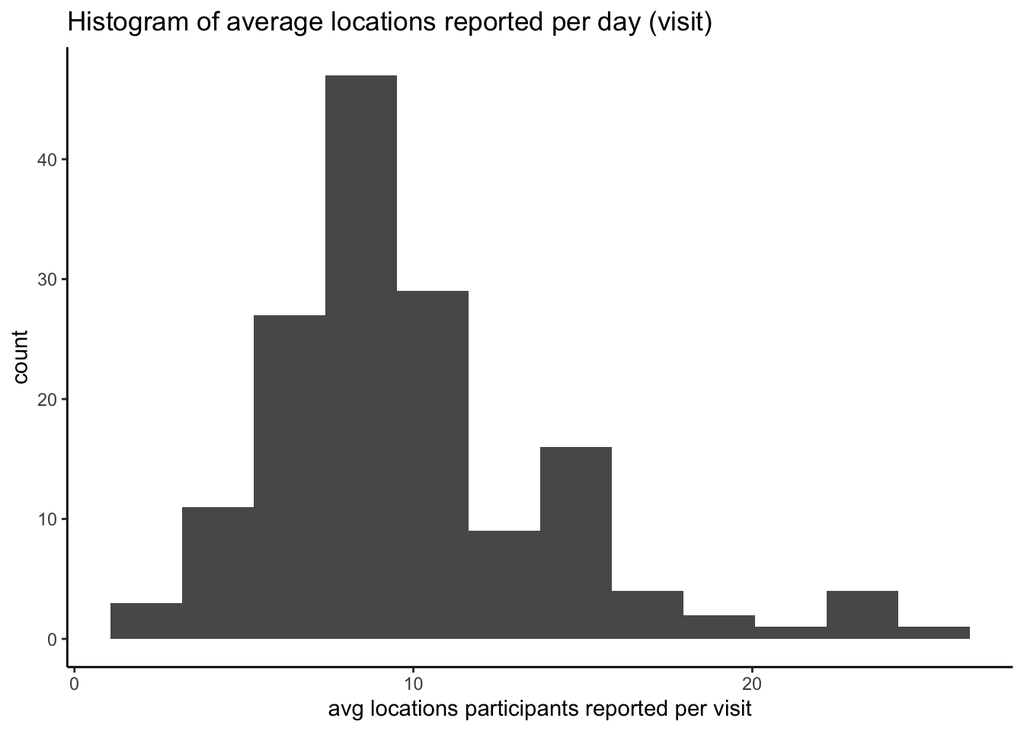

```r
mean_avg_location_per_day <- locations %>%
  group_by(subid, date(time_central)) %>%
  summarise(n_obs = n()) %>%
  group_by(subid) %>%
  summarise(avg_locations_per_day = mean(n_obs)) %>%
  .$avg_locations_per_day %>%
  mean()

max_location_per_day <- locations %>%
  group_by(subid, date(time_central)) %>%
  summarise(n_obs = n()) %>%
  group_by(subid) %>%
  summarise(max = max(n_obs)) %>%
  .$max %>% max()

locations %>%
  group_by(subid, date(time_central)) %>%
  summarise(n_obs = n()) %>%
  group_by(subid) %>%
  summarise(avg_locations_per_day = mean(n_obs)) %>%
  ggplot(aes(x = avg_locations_per_day)) +
  geom_histogram(bins = 12) +
  xlab("avg locations participants reported per visit") +
  ggtitle("Histogram of average locations reported per day (visit)") +
  theme_classic()
```

On average, participants reported an average of 9.96 places visisted at their intake/followup visits (max = 58).

COMMENT KW 2020-08-11: The goal would be to use the above script to report the places participants visited each day if we can combine these locations with GPS data. Currently it probably does not tell us much because we would expect participants reported more locations at intake and fewer at followups.

Type of location (type)

```r
locations %>%
  mutate(type = tolower(type),
         type = fct_infreq(factor(type))) %>%
  tabyl(type, show_na = TRUE) %>%
  adorn_totals("row") %>%
  kable(caption = "Type of location", table.attr = "style='width:60%;'") %>%
  kable_styling(position = "left")
```

Type of location

| type | n | percent | valid_percent |
| --- | --- | --- | --- |
| errands | 1338 | 0.2557828 | 0.2558807 |
| other | 832 | 0.1590518 | 0.1591126 |
| restaurant | 568 | 0.1085834 | 0.1086250 |
| work | 547 | 0.1045689 | 0.1046089 |
| home of friend | 323 | 0.0617473 | 0.0617709 |
| home of family member | 273 | 0.0521889 | 0.0522088 |
| health care | 237 | 0.0453068 | 0.0453242 |
| park | 200 | 0.0382336 | 0.0382482 |
| home | 176 | 0.0336456 | 0.0336584 |
| bar | 171 | 0.0326897 | 0.0327022 |
| aa/recovery meeting | 163 | 0.0311604 | 0.0311723 |
| coffee shop/cafe | 129 | 0.0246607 | 0.0246701 |
| liquor store | 80 | 0.0152934 | 0.0152993 |
| gym/fitness center | 76 | 0.0145288 | 0.0145343 |
| school | 64 | 0.0122348 | 0.0122394 |
| volunteer | 27 | 0.0051615 | 0.0051635 |
| church | 25 | 0.0047792 | 0.0047810 |
| NA | 2 | 0.0003823 | NA |
| Total | 5231 | 1.0000000 | 1.0000000 |

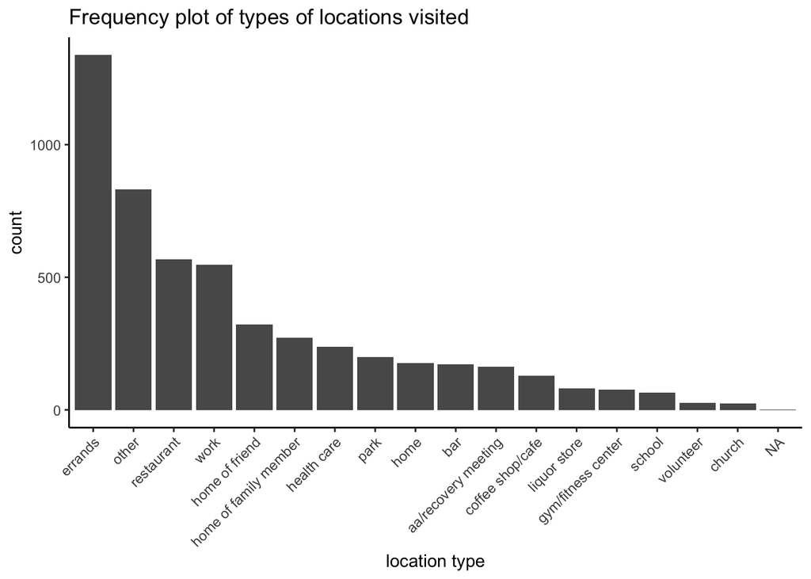

```r
locations %>%
  mutate(type = tolower(type),
         type = fct_infreq(factor(type))) %>%
  ggplot(aes (x = type)) +
  geom_bar() +
  xlab("location type") +
  ggtitle("Frequency plot of types of locations visited") +
  theme_classic() +
  theme(axis.text.x = element_text(angle = 45, hjust = 1))
```

Location as a function of risk level

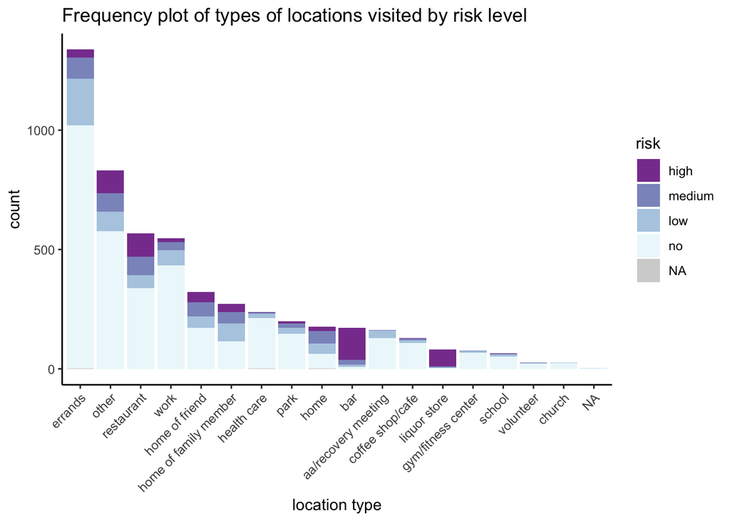

```r
locations %>%
  mutate(type = tolower(type),
         type = fct_infreq(factor(type))) %>%
  mutate(risk = tolower(risk),
         risk = fct_relevel(factor(risk, c("high", "medium", "low", "no", "NA")))) %>%
  ggplot(aes (x = type, fill = risk)) +
  geom_bar() +
  xlab("location type") +
  ggtitle("Frequency plot of types of locations visited by risk level") +
  theme_classic() +
  theme(axis.text.x = element_text(angle = 45, hjust = 1)) +
  scale_fill_brewer(palette = "BuPu", direction = -1, na.value = "light grey")
```

Drank alcohol at location in past (drank)

```r
locations %>%
  mutate(drank = tolower(drank),
         drank = fct_infreq(factor(drank))) %>%
  tabyl(drank, show_na = TRUE) %>%
  adorn_totals("row") %>%
  kable(caption = "Drank alcohol at location in past", table.attr = "style='width:50%;'") %>%
  kable_styling(position = "left")
```

Drank alcohol at location in past

| drank | n | percent | valid_percent |
| --- | --- | --- | --- |
| no | 3926 | 0.7505257 | 0.7506692 |
| yes | 1304 | 0.2492831 | 0.2493308 |
| NA | 1 | 0.0001912 | NA |
| Total | 5231 | 1.0000000 | 1.0000000 |

Alcohol is available at location (alcohol)

```r
locations %>%
  mutate(alcohol = tolower(alcohol),
         alcohol = fct_infreq(factor(alcohol))) %>%
  tabyl(alcohol, show_na = TRUE) %>%
  adorn_totals("row") %>%
  kable(caption = "Alcohol is available at location", table.attr = "style='width:50%;'") %>%
  kable_styling(position = "left")
```

Alcohol is available at location

| alcohol | n | percent | valid_percent |
| --- | --- | --- | --- |
| no | 2839 | 0.5427261 | 0.5428298 |
| yes | 2391 | 0.4570828 | 0.4571702 |
| NA | 1 | 0.0001912 | NA |
| Total | 5231 | 1.0000000 | 1.0000000 |

Emotion associated with location (emotion)

```r
locations %>%
  mutate(emotion = tolower(emotion),
         emotion = fct_relevel(factor(emotion, c("pleasant", "unpleasant", "mixed", "neutral")))) %>%
  tabyl(emotion, show_na = TRUE) %>%
  adorn_totals("row") %>%
  kable(caption = "Emotion associated with location", table.attr = "style='width:50%;'") %>%
  kable_styling(position = "left")
```

Emotion associated with location

| emotion | n | percent | valid_percent |
| --- | --- | --- | --- |
| pleasant | 3597 | 0.6876314 | 0.6880260 |
| unpleasant | 156 | 0.0298222 | 0.0298393 |
| mixed | 673 | 0.1286561 | 0.1287299 |
| neutral | 802 | 0.1533168 | 0.1534047 |
| NA | 3 | 0.0005735 | NA |
| Total | 5231 | 1.0000000 | 1.0000000 |

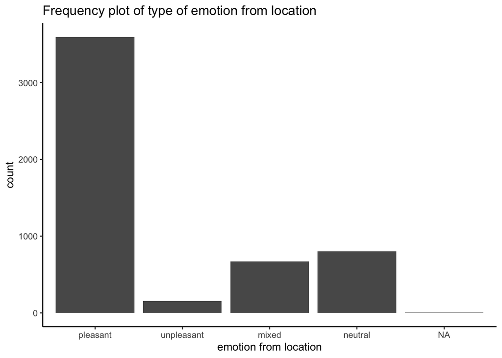

```r
locations %>%
  mutate(emotion = tolower(emotion),
         emotion = fct_relevel(factor(emotion, c("pleasant", "unpleasant", "mixed", "neutral", "NA")))) %>%
  ggplot(aes (x = emotion)) +
  geom_bar() +
  xlab("emotion from location") +
  ggtitle("Frequency plot of type of emotion from location") +
  theme_classic()
```

Risk level for drinking (risk)

```r
locations %>%
  mutate(risk = tolower(risk),
         risk = fct_relevel(factor(risk, c("high", "medium", "low", "no")))) %>%
  tabyl(risk, show_na = TRUE) %>%
  adorn_totals("row") %>%
  kable(caption = "Risk level for drinking at location", table.attr = "style='width:50%;'") %>%
  kable_styling(position = "left")
```

Risk level for drinking at location

| risk | n | percent | valid_percent |
| --- | --- | --- | --- |
| high | 559 | 0.1068629 | 0.1069243 |
| medium | 498 | 0.0952017 | 0.0952563 |
| low | 685 | 0.1309501 | 0.1310252 |
| no | 3486 | 0.6664118 | 0.6667942 |
| NA | 3 | 0.0005735 | NA |
| Total | 5231 | 1.0000000 | 1.0000000 |

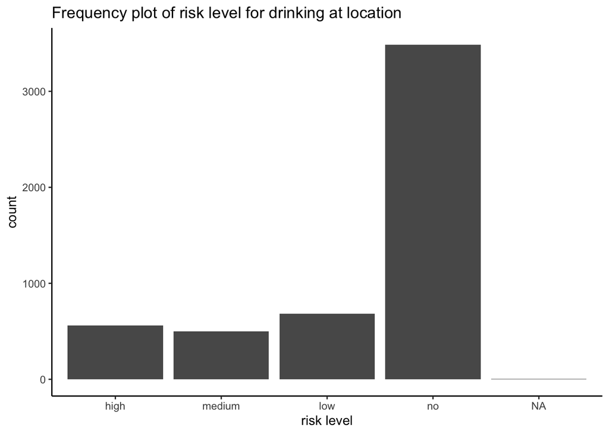

```r
locations %>%
  mutate(risk = tolower(risk),
         risk = fct_relevel(factor(risk, c("high", "medium", "low", "no", "NA")))) %>%
  ggplot(aes (x = risk)) +
  geom_bar() +
  xlab("risk level") +
  ggtitle("Frequency plot of risk level for drinking at location") +
  theme_classic()
```

Avoiding location (avoid)

```r
locations %>%
  mutate(avoid = tolower(avoid)) %>%
  tabyl(avoid, show_na = TRUE) %>%
  adorn_totals("row") %>%
  kable(caption = "Location participant avoids", table.attr = "style='width:50%;'") %>%
  kable_styling(position = "left")
```

Location participant avoids

| avoid | n | percent |
| --- | --- | --- |
| no | 5000 | 0.9558402 |
| yes | 231 | 0.0441598 |
| Total | 5231 | 1.0000000 |

Vacation location (vacation)

```r
locations %>%
  mutate(vacation = tolower(vacation)) %>%
  tabyl(vacation, show_na = TRUE) %>%
  adorn_totals("row") %>%
  kable(caption = "Location participant vacations at", table.attr = "style='width:50%;'") %>%
  kable_styling(position = "left")
```

Location participant vacations at

| vacation | n | percent | valid_percent |
| --- | --- | --- | --- |
| no | 4972 | 0.9504875 | 0.9605873 |
| yes | 204 | 0.0389983 | 0.0394127 |
| NA | 55 | 0.0105142 | NA |
| Total | 5231 | 1.0000000 | 1.0000000 |